# Notebook report

## Creative Gaming: Propensity-to-Buy

##### Group members - Akansha Lalwani, Rijul Sherathia, Golokesh Patra

#### Part I: Exploratory Analytics (2 points)

1. What is the probability of organically converting to Zalon? (1 point)

```r
result <- pivotr(
  cg_organic,
  cvars = "converted",
  normalize = "total",
  nr = Inf
)
# summary(result)
dtab(result, perc = TRUE, dec = 2, caption = "") %>% render()
```

[interactive table not shown]

Probability of organically converting to Zalon - 5.75%

2. Use Data > Explore in Radiant to show basic summary statistics for each feature in the data. Include n_obs, n_missing, n_distinct, mean, min, max, and sd. (1 point)

```r
result <- explore(
  cg_organic,
  vars = c(
    "converted", "GameLevel",
    "NumGameDays", "NumGameDays4Plus",
    "NumInGameMessagesSent",
    "NumSpaceHeroBadges",
    "NumFriendRequestIgnored",
    "NumFriends", "AcquiredSpaceship",
    "AcquiredIonWeapon",
    "TimesLostSpaceship",
    "TimesKilled", "TimesCaptain",
    "TimesNavigator", "PurchasedCoinPackSmall",
    "PurchasedCoinPackLarge",
    "NumAdsClicked", "DaysUser",
    "UserConsole", "UserHasOldOS",
    "training"
  ),
  fun = c("n_obs", "n_missing", "n_distinct", "mean", "min", "max", "sd"),
  nr = Inf
)
# summary(result)
dtab(result, caption = "") %>% render()
```

[interactive table not shown]

#### Part II: Predictive Model (5 points)

Train a logistic regression model using all features and use the “training” variable to set a filter (“training == 1”).

Hint: Renaming the output from the logistic regression model from “result” to “lr_organic” will help ensure you won’t need to re-estimate the logistic regression model later on. This step is not required, however.

1. What are the 5 most important features? (1 point)

```r
lr_organic <- logistic(
  cg_organic,
  rvar = "converted",
  evar = c(
    "GameLevel", "NumGameDays",
    "NumGameDays4Plus", "NumInGameMessagesSent",
    "NumSpaceHeroBadges",
    "NumFriendRequestIgnored",
    "NumFriends", "AcquiredSpaceship",
    "AcquiredIonWeapon",
    "TimesLostSpaceship",
    "TimesKilled", "TimesCaptain",
    "TimesNavigator", "PurchasedCoinPackSmall",
    "PurchasedCoinPackLarge",
    "NumAdsClicked", "DaysUser",
    "UserConsole", "UserHasOldOS"
  ),
  lev = "yes",
  data_filter = "training == 1"
)
summary(lr_organic)
```

```
Logistic regression (GLM)
Data                 : cg_organic
Filter               : training == 1
Response variable    : converted
Level                : yes in converted
Explanatory variables: GameLevel, NumGameDays, NumGameDays4Plus, NumInGameMessagesSent, NumSpaceHeroBadges, NumFriendRequestIgnored, NumFriends, AcquiredSpaceship, AcquiredIonWeapon, TimesLostSpaceship, TimesKilled, TimesCaptain, TimesNavigator, PurchasedCoinPackSmall, PurchasedCoinPackLarge, NumAds…
Null hyp.: there is no effect of x on converted
Alt. hyp.: there is an effect of x on converted

                               OR    OR% coefficient std.error z.value p.value
 (Intercept)                                  -4.755     0.190 -24.998  < .001 ***
 GameLevel                  1.109  10.9%       0.104     0.014   7.380  < .001 ***
 NumGameDays                1.034   3.4%       0.033     0.005   6.058  < .001 ***
 NumGameDays4Plus           1.042   4.2%       0.041     0.009   4.648  < .001 ***
 NumInGameMessagesSent      1.001   0.1%       0.001     0.000   3.961  < .001 ***
 NumSpaceHeroBadges         1.519  51.9%       0.418     0.013  31.961  < .001 ***
 NumFriendRequestIgnored    0.988  -1.2%      -0.012     0.001  -9.181  < .001 ***
 NumFriends                 1.001   0.1%       0.001     0.000   4.201  < .001 ***
 AcquiredSpaceship|yes      1.713  71.3%       0.538     0.072   7.486  < .001 ***
 AcquiredIonWeapon|yes      1.613  61.3%       0.478     0.203   2.353   0.019 *
 TimesLostSpaceship         0.961  -3.9%      -0.040     0.005  -7.627  < .001 ***
 TimesKilled                0.984  -1.6%      -0.016     0.017  -0.940   0.347
 TimesCaptain               0.997  -0.3%      -0.003     0.004  -0.873   0.383
 TimesNavigator             0.977  -2.3%      -0.024     0.007  -3.608  < .001 ***
 PurchasedCoinPackSmall|yes 0.912  -8.8%      -0.092     0.070  -1.316   0.188
 PurchasedCoinPackLarge|yes 1.270  27.0%       0.239     0.073   3.257   0.001 **
 NumAdsClicked              1.027   2.7%       0.027     0.004   7.183  < .001 ***
 DaysUser                   1.000  -0.0%      -0.000     0.000  -0.135   0.893
 UserConsole|yes            1.203  20.3%       0.185     0.091   2.025   0.043 *
 UserHasOldOS|yes           0.847 -15.3%      -0.166     0.124  -1.341   0.180

Signif. codes:  0 '***' 0.001 '**' 0.01 '*' 0.05 '.' 0.1 ' ' 1

Pseudo R-squared:0.184, Adjusted Pseudo R-squared:0.18
AUC: 0.82, Log-likelihood: -3719.041, AIC: 7478.081, BIC: 7637.127
Chi-squared: 1682.617 df(19), p.value < .001
Nr obs: 21,000
```

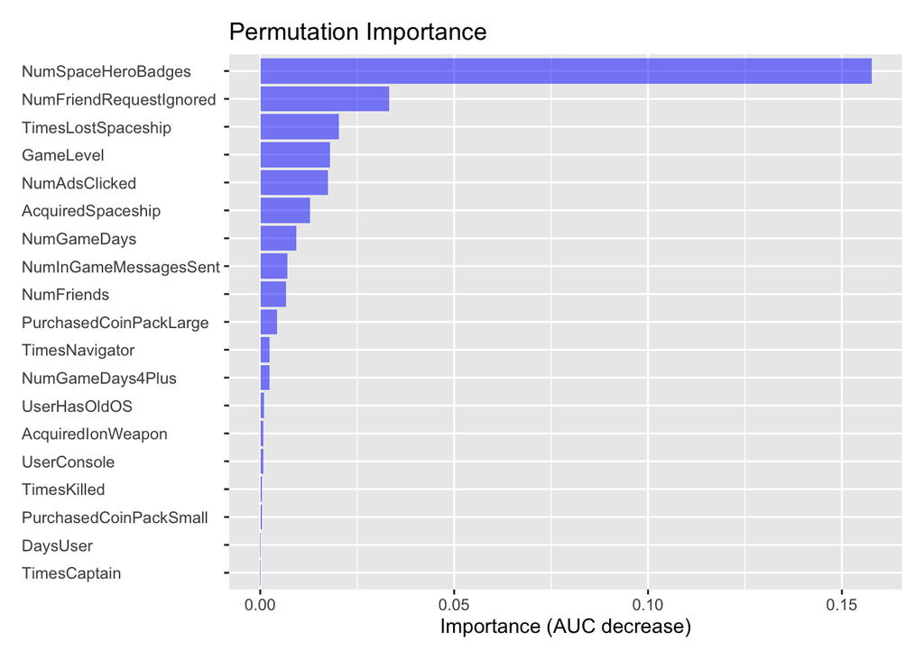

```r
plot(lr_organic, plots = "vip", custom = FALSE)
```

From the Permutation Importance plot, we can see that the 5 most important features are “NumSpaceHeroBadges”, “NumFriendRequestIgnored”, “TimesLostSpaceship”, “GameLevel”, and “NumAdsClicked”

2. Generate Partial Dependence plots for each of these 5 features and summarize your findings (1 point)

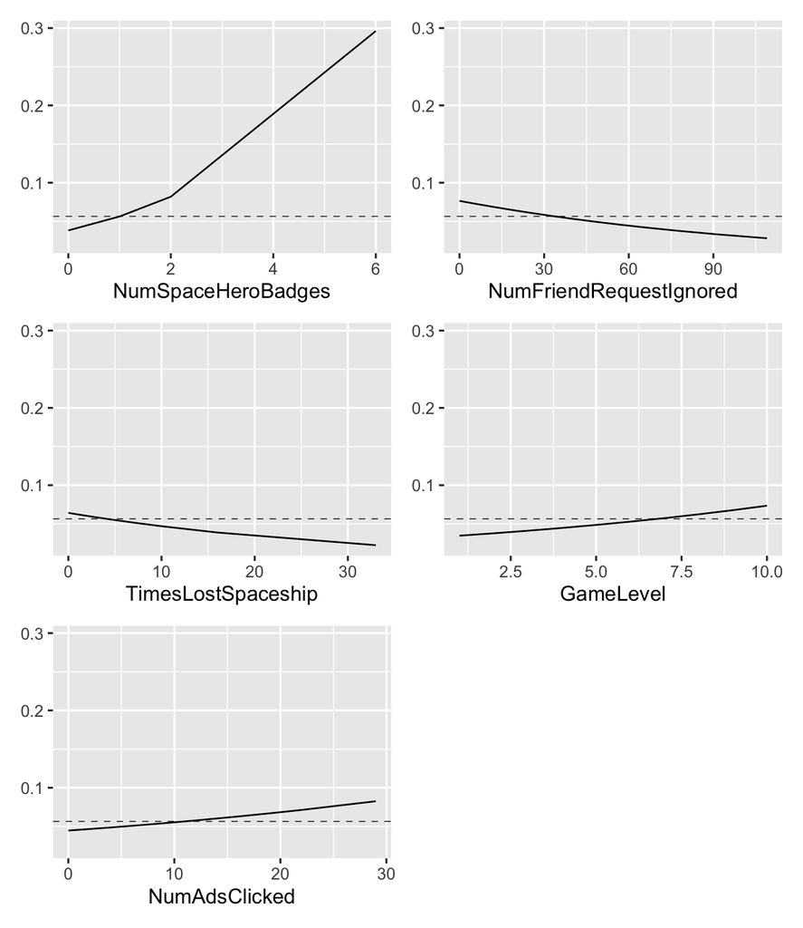

```r
plot(
  lr_organic,
  plots = "pdp",
  incl = c(
    "NumSpaceHeroBadges",
    "NumFriendRequestIgnored",
    "TimesLostSpaceship",
    "GameLevel",
    "NumAdsClicked"
  ),
  custom = FALSE
)
```

NumSpaceHeroBadges indicates a strong positive effect, keeping all other variables in the model constant. The likelihood of a gamer investing in the Salon campaign appears to rise with each badge earned. This trend may reflect the gamer’s proficiency and active participation in the game.

Conversely, NumFriendRequestIgnored and TimesLostSpaceShip suggest negative effects, keeping all other variables in the model constant. As the frequency of ignored friend requests and instances of losing a spaceship go up, there’s an implied decrease in the possibility of a gamer purchasing the Salon campaign. These patterns could be indicative of lesser skill and a potentially reduced level of engagement within the game.

We see positive effects for GameLevel and NumAdsClicked, keeping all other variables in the model constant. With the increase in GameLevel and the number of ads clicked, there seems to be an uptick in the gamer’s chances of engaging with the Salon campaign. Advancement in game levels may signify a player’s skill and commitment, whereas interacting with advertisements may indicate an openness to new promotions.

3. Create a new variable “pred_logit” with predictions from the logistic regression model for all rows in the data (1 point)

```r
pred <- predict(lr_organic, pred_data = cg_organic)
print(pred, n = 10)
```

```
Logistic regression (GLM)
Data                 : cg_organic
Filter               : training == 1
Response variable    : converted
Level(s)             : yes in converted
Explanatory variables: GameLevel, NumGameDays, NumGameDays4Plus, NumInGameMessagesSent, NumSpaceHeroBadges, NumFriendRequestIgnored, NumFriends, AcquiredSpaceship, AcquiredIonWeapon, TimesLostSpaceship, TimesKilled, TimesCaptain, TimesNavigator, PurchasedCoinPackSmall, PurchasedCoinPackLarge, NumAds…
Interval             : confidence
Prediction dataset   : cg_organic
Rows shown           : 10 of 30,000

 GameLevel NumGameDays NumGameDays4Plus NumInGameMessagesSent NumSpaceHeroBadges NumFriendRequestIgnored NumFriends AcquiredSpaceship AcquiredIonWeapon TimesLostSpaceship TimesKilled TimesCaptain TimesNavigator PurchasedCoinPackSmall
        10          11                0                   355                  0                       8          3               yes                no                  6           0            5              0                     no
         6           7                1                    30                  0                       0          0               yes                no                  4           0            0              0                     no
         8           2                0                    69                  0                     111         13                no                no                  2           0            0              0                    yes
         5           3                0                    40                  0                      33          1                no                no                  0           0            2              0                     no
         6          15                0                     5                  0                      62          0                no                no                  0           0            0              0                     no
         1           8                0                     0                  0                       0         12                no                no                  0           0            0              0                    yes
         5           7                0                     0                  0                       0          0                no                no                  0           0            0              0                     no
         9           1                0                     0                  0                       0         36               yes                no                  0           0            2              0                    yes
        10           2                0                   134                  0                      91          5                no                no                 19           0            0              0                    yes
         7          22                3                   195                  0                     105          0                no                no                  1           0            4              0                     no
 PurchasedCoinPackLarge NumAdsClicked DaysUser UserConsole UserHasOldOS Prediction  2.5% 97.5%
                     no             4     2953         yes          yes      0.073 0.052 0.103
                    yes             8     2343         yes           no      0.057 0.047 0.068
                     no            11     2374         yes           no      0.008 0.006 0.011
                     no             3     2708         yes           no      0.014 0.012 0.017
                     no            11     2101         yes          yes      0.017 0.013 0.023
                     no             0     2254         yes           no      0.013 0.011 0.017
                     no             4     4139         yes           no      0.023 0.019 0.028
                     no            10     2282         yes           no      0.054 0.043 0.067
                     no             5     2343         yes           no      0.006 0.005 0.009
                     no             5     2404         yes          yes      0.017 0.012 0.024
```

```r
cg_organic <- store(cg_organic, pred, name = "pred_logit")
```

4. Plot gains curves for both the training and test set using the “pred_logit” variable (use Model > Evaluate Classification > Evaluate) (1 point)

```r
result <- evalbin(
  cg_organic,
  pred = "pred_logit",
  rvar = "converted",
  lev = "yes",
  train = "Both",
  data_filter = "training == 1"
)
summary(result, prn = FALSE)
```

```
Evaluate predictions for binary response models
Data        : cg_organic
Filter      : training == 1
Results for : Both
Predictors  : pred_logit
Response    : converted
Level       : yes in converted
Bins        : 10
Cost:Margin : 1 : 2
Scale       : 1
```

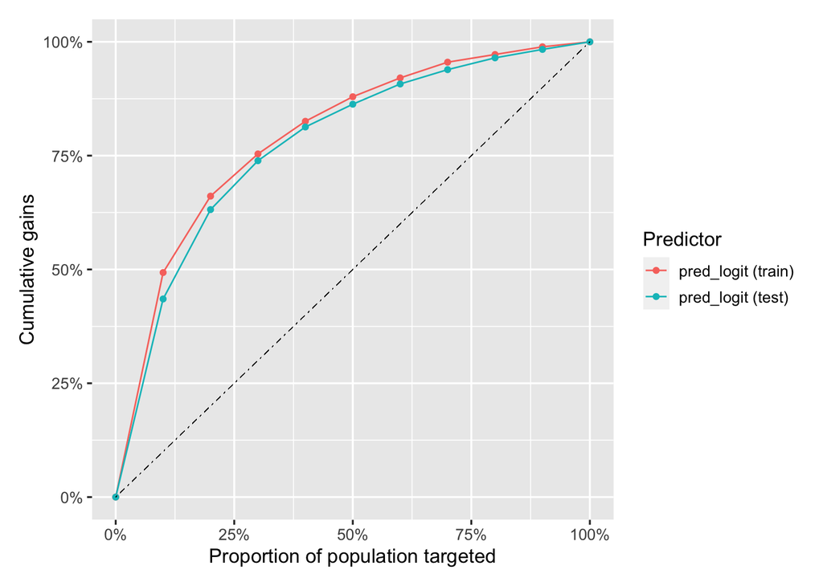

```r
plot(result, plots = "gains", custom = FALSE)
```

5. Report the AUC of the model in both the training and test set (use Model > Evaluate Classification > Confusion) (1 point)

```r
result <- confusion(
  cg_organic,
  pred = "pred_logit",
  rvar = "converted",
  lev = "yes",
  train = "Both",
  data_filter = "training == 1"
)
summary(result)
```

```
Confusion matrix
Data       : cg_organic
Filter     : training == 1
Results for: Both
Predictors : pred_logit
Response   : converted
Level      : yes in converted
Cost:Margin: 1 : 2
Scale      : 1

     Type  Predictor  TP  FP     TN    FN  total   TPR   TNR precision Fscore
 Training pred_logit 148 130 19,684 1,038 21,000 0.125 0.993     0.532  0.202
     Test pred_logit  56  56  8,404   484  9,000 0.104 0.993     0.500  0.172

     Type  Predictor accuracy kappa profit index  ROME contact   AUC
 Training pred_logit    0.944 0.185 18.000 1.000 0.065   0.013 0.820
     Test pred_logit    0.940 0.154  0.000   NaN 0.000   0.012 0.803
```

AUC Training - 0.820

AUC Test - 0.803

#### Part III: The Ad-Experiment (12 points)

You have finished building a logistic regression model to predict what kind of Space Pirates gamers were more or less likely to purchase the Zalon campaign. After debriefing Mi Haruki on the performance of the predictive model, she lays out the next steps:

“We will test the effectiveness of the in-app ad and the predictive model by exposing a random 150,000 customers to a 2-week ad campaign and measuring their conversion to Zalon over the next 2 months. At the same time, we will randomly pick another 30,000 customers and observe their organic upgrade behavior over the same period. This set of customers will not be served any in-app ads.

I want you to compare three groups based on this data.

Group 1: The randomly picked 30,000 Space Pirates gamers who did not receive in-app ads during the experimental period.

Group 2: A randomly picked 30,000 Space Pirates gamers among the 150,000 who were served in-app ads for Zalon.

Group 3: A model-selected 30,000 Space Pirates gamers among the 120,000 (after taking out Group 2) who were served in-app ads for Zalon.

Please report back to me how well the ads are working in terms of conversion rates and profits and by how much the model improves these metrics, all based on targeting 30,000 customers. To calculate profits, please use revenues of $14.99 from selling Zalon. The cost of serving ads to a consumer for 2 weeks is $1.50 in lost coin purchases.”

1. Calculate the response rate and profit of group 1. The dataset containing the data for group 1 is named “data/cg_organic_control.rds”. (2 points)

```r
result <- pivotr(
  cg_organic_control,
  cvars = "converted",
  normalize = "total",
  nr = Inf
)
# summary(result)
dtab(result, dec = 5, caption = "") %>% render()
```

[interactive table not shown]

```r
result <- pivotr(
  cg_organic_control,
  cvars = "converted",
  nr = Inf
)
# summary(result)
dtab(result, dec = 5, caption = "") %>% render()
```

[interactive table not shown]

```r
revenue = 14.99
customers = 30000
cost = 1.5
```

```r
response_rate_group1 = 0.0568
converted_yes_group1 = 1706
profit_group1 = converted_yes_group1 * revenue
profit_group1
```

```
[1] 25572.94
```

Response rate of group 1 - 0.0568

Profit of group 1 - 25,572.94

The dataset needed to evaluate groups 2 and 3 is “data/cg_ad_treatment.rds”. All customers in this dataset were exposed to advertising as part of the experiment.

2. Calculate the response rate and profit of group 2. Set a filter “rnd_30k == 1” to select the 30,000 customers from the 150,000 rows in “cg_ad_treatment”. (2 points)

```r
result <- pivotr(
  cg_ad_treatment,
  cvars = "converted",
  data_filter = "rnd_30k == 1",
  nr = Inf
)
# summary(result)
dtab(result, dec = 5, caption = "") %>% render()
```

[interactive table not shown]

```r
result <- pivotr(
  cg_ad_treatment,
  cvars = "converted",
  normalize = "total",
  data_filter = "rnd_30k == 1",
  nr = Inf
)
# summary(result)
dtab(result, dec = 5, caption = "") %>% render()
```

[interactive table not shown]

```r
response_rate_group2 = 0.130433
converted_yes_group2 = 3913
profit_group2 = converted_yes_group2 * revenue - customers * cost
profit_group2
```

```
[1] 13655.87
```

Response rate of group 2 - 0.13043

Profit of group 2 - 13,655.87

3. Calculate the response rate and profit of group 3. To do this please:
1. Use the logistic regression model you trained in Part II to predict the probability of purchasing the Zalon campaign (i.e., score) all 150,000 gamers in the “cg_ad_treatment”. (1 point)

```r
pred <- predict(lr_organic, pred_data = cg_ad_treatment)
print(pred, n = 10)
```

```
Logistic regression (GLM)
Data                 : cg_organic
Filter               : training == 1
Response variable    : converted
Level(s)             : yes in converted
Explanatory variables: GameLevel, NumGameDays, NumGameDays4Plus, NumInGameMessagesSent, NumSpaceHeroBadges, NumFriendRequestIgnored, NumFriends, AcquiredSpaceship, AcquiredIonWeapon, TimesLostSpaceship, TimesKilled, TimesCaptain, TimesNavigator, PurchasedCoinPackSmall, PurchasedCoinPackLarge, NumAds…
Interval             : confidence
Prediction dataset   : cg_ad_treatment
Rows shown           : 10 of 150,000

 GameLevel NumGameDays NumGameDays4Plus NumInGameMessagesSent NumSpaceHeroBadges NumFriendRequestIgnored NumFriends AcquiredSpaceship AcquiredIonWeapon TimesLostSpaceship TimesKilled TimesCaptain TimesNavigator PurchasedCoinPackSmall
         6          16                0                     0                  0                       0          0               yes                no                  0           0            0              0                     no
         2           8                0                     0                  0                       5          4                no                no                  0           0            8              0                    yes
         6           1                0                     0                  0                       0          0                no                no                  0           0            0              0                     no
         7          16                0                   102                  1                       0        194                no                no                  0           0            0              0                    yes
        10           1                1                   233                  0                      23          0                no                no                  3           0            5              0                     no
         1           6                0                     0                  0                       0          0                no                no                  4           0            0              0                     no
         2           4                0                     0                  0                       0          0               yes                no                  3           0            0              0                     no
         1           9                0                     0                  0                       0          0                no                no                  0           0            0              0                    yes
         8           9                0                     4                  0                      98          2                no                no                  1           0            0              9                     no
        10          11                0                     0                  9                       0        244                no                no                  0           0            4              0                     no
 PurchasedCoinPackLarge NumAdsClicked DaysUser UserConsole UserHasOldOS Prediction  2.5% 97.5%
                     no            11     1827          no           no      0.058 0.047 0.073
                     no             3     1889          no          yes      0.010 0.007 0.015
                    yes             2     1948         yes           no      0.026 0.021 0.032
                    yes            21     3409         yes          yes      0.122 0.092 0.160
                    yes             4     2922         yes           no      0.039 0.030 0.051
                    yes             9     3470         yes           no      0.019 0.015 0.023
                     no             3     4108         yes           no      0.023 0.018 0.029
                    yes             0     2892          no           no      0.014 0.011 0.019
                     no            14     3835         yes           no      0.011 0.008 0.015
                     no             9     1461          no           no      0.719 0.649 0.780
```

```r
cg_ad_treatment <- store(cg_ad_treatment, pred, name = "pred_logit")
```

2. Select the 30,000 customers with best predictions (scores) that are not part of group 2. Use only these 30,000 to compute conversion rates and profits of group 3. (1 point)

Hint: Use “rnd_30k == 0” as the filter, “desc(pred_logit)” in the Arrange input, and “1:30000” in the Slice input to select this set of customers.

```r
result <- pivotr(
  cg_ad_treatment,
  cvars = "converted",
  data_filter = "rnd_30k == 0",
  arr = "desc(pred_logit)",
  rows = "1:30000",
  nr = Inf
)
# summary(result)
dtab(result, dec = 5, caption = "") %>% render()
```

[interactive table not shown]

```r
result <- pivotr(
  cg_ad_treatment,
  cvars = "converted",
  normalize = "total",
  data_filter = "rnd_30k == 0",
  arr = "desc(pred_logit)",
  rows = "1:30000",
  nr = Inf
)
# summary(result)
dtab(result, dec = 5, caption = "") %>% render()
```

[interactive table not shown]

```r
response_rate_group3 = 0.21507
converted_yes_group3 = 6452
profit_group3 = converted_yes_group3 * revenue - customers * cost
profit_group3
```

```
[1] 51715.48
```

Response rate of group 3 - 0.21507

Profit of group 3 - 51,715.48

4. Answer Mi Haruki’s question: “Please report back to me how well the ads are working in terms of conversion rates and profits and by how much the model improves these metrics, all based on targeting 30,000 customers.” (2 points)

Response rate of group 1 - 0.0568

Profit of group 1 - 25,572.94

Response rate of group 2 - 0.13043

Profit of group 2 - 13,655.87

Response rate of group 3 - 0.21507

Profit of group 3 - 51,715.48

In the context of the ad experiment conducted, the impact on conversion rates and profitability across the three distinct groups showed varied outcomes.

Group 1, which comprised 30,000 Space Pirates gamers who were not exposed to any in-app advertisements, exhibited a conversion rate of 5.69%. The revenue generated by this group, absent any advertising cost, culminated in a profit of $25,573.

When examining Group 2, which also consisted of 30,000 Space Pirates gamers but from the subset that did receive in-app advertisements for Zalon, there was an elevation in the conversion rate to 13.04%. However, when considering the associated costs of running the ads, the profit for this group experienced a downturn, settling at $13,656.

Group 3, the cohort selected by the predictive model from the remaining 120,000 gamers who were served ads, demonstrated the potency of targeted advertising. The conversion rate soared to 21.51% for these gamers. More importantly, the profit escalated dramatically to $51,715, even after factoring in the costs of advertising.

Analyzing the financial benefit of the ad campaign, particularly when leveraging the predictive model for customer selection, reveals a substantial gain. Specifically, the profit for Group 3 exceeds that of Group 1 by $26,143, illustrating the added value of data-driven targeting in advertising strategies. This result underscores the efficacy of the predictive model in not only enhancing conversion rates but also in substantially improving profit margins.

5. Plot the gains curve for all customers that are not in group 2 (i.e., rnd_30k == 0). Also report the AUC of the for this set of customers. Compare the gains curve and AUC to the ones you calculated in Part II.4 and II.5. Why are they different? (2 points)

```r
result <- evalbin(
  cg_ad_treatment,
  pred = "pred_logit",
  rvar = "converted",
  lev = "yes",
  train = "Both",
  data_filter = "rnd_30k == 0"
)
summary(result, prn = FALSE)
```

```
Evaluate predictions for binary response models
Data        : cg_ad_treatment
Filter      : rnd_30k == 0
Results for : Both
Predictors  : pred_logit
Response    : converted
Level       : yes in converted
Bins        : 10
Cost:Margin : 1 : 2
Scale       : 1
```

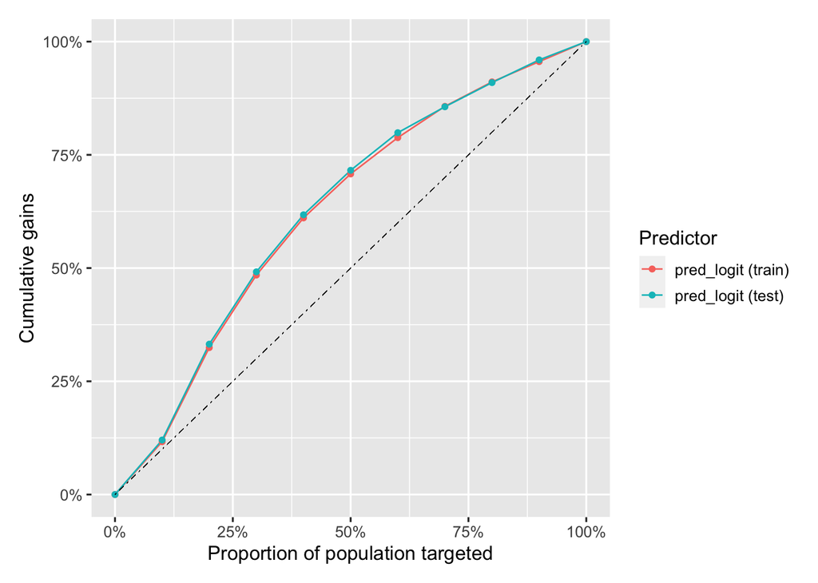

```r
plot(result, plots = "gains", custom = FALSE)
```

```r
result <- confusion(
  cg_ad_treatment,
  pred = "pred_logit",
  rvar = "converted",
  lev = "yes",
  train = "Both",
  data_filter = "rnd_30k == 0"
)
summary(result)
```

```
Confusion matrix
Data       : cg_ad_treatment
Filter     : rnd_30k == 0
Results for: Both
Predictors : pred_logit
Response   : converted
Level      : yes in converted
Cost:Margin: 1 : 2
Scale      : 1

     Type  Predictor  TP    FP      TN     FN   total   TPR   TNR precision Fscore
 Training pred_logit 385 3,948 100,317 15,350 120,000 0.024 0.962     0.089  0.038
     Test pred_logit 114   975  25,112  3,799  30,000 0.029 0.963     0.105  0.046

     Type  Predictor accuracy  kappa     profit index   ROME contact   AUC
 Training pred_logit    0.839 -0.019 -3,563.000 1.000 -0.822   0.036 0.644
     Test pred_logit    0.841 -0.012   -861.000 1.000 -0.791   0.036 0.651
```

AUC - 0.644

Comapring with gains curve and AUC in Part II.4 and II.5,

```r
result <- evalbin(
  cg_organic,
  pred = "pred_logit",
  rvar = "converted",
  lev = "yes",
  train = "Both",
  data_filter = "training == 1"
)
summary(result, prn = FALSE)
```

```
Evaluate predictions for binary response models
Data        : cg_organic
Filter      : training == 1
Results for : Both
Predictors  : pred_logit
Response    : converted
Level       : yes in converted
Bins        : 10
Cost:Margin : 1 : 2
Scale       : 1
```

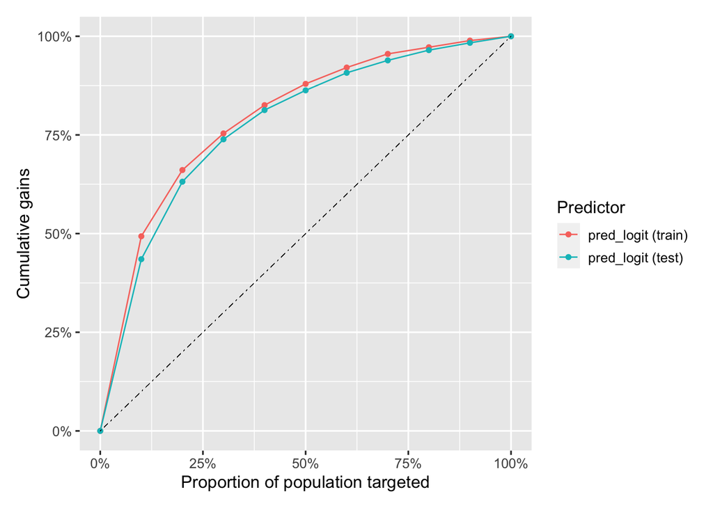

```r
plot(result, plots = "gains", custom = FALSE)
```

AUC Training - 0.820

AUC Test - 0.803

The outcomes from the gains curve and Area Under the Curve (AUC) metric for the customer set excluding Group 2 (those indicated by `rnd_30k == 0`) are observed to be diminished when compared to the results obtained in Part II. This discrepancy can be attributed to the differing contexts in which the model was applied.

During Part II, the model was both trained and evaluated on data reflecting organic conversion behaviors. In Part III, although we used the same model, we predictive the model by exposing to a 2-week ad campaign. This shift in the prediction environment could be the primary cause for the reduced performance metrics seen in Part III.

The concept of “situational invariance” is crucial here — it refers to the assumption that the conditions under which a model is trained should ideally be consistent with the conditions under which it is tested. Since the model was originally calibrated to predict organic adoption without the presence of ad, its application to a situation where ad influence is present does not align with the original training context. Consequently, the model’s predictive accuracy is naturally expected to be lower in scenarios where the influencing factors differ from those in the training data.

6. What could be the value of collecting data for group 1 (cg_organic_control) given that we already had data on organic conversions from the cg_organic data? (2 points)

Probability of organically converting to Zalon (cg_organic) - 5.75%

Response rate of group 1 (cg_organic_control) - 5.68%

The collection of Group 1 data, termed “cg_organic_control,” serves as a vital contemporary benchmark, even with prior information on organic conversion trends from “cg_organic.” This data acts as a fresh control group, crucial for assessing the current market conditions and user responses which may have evolved from the period when the previous organic data was collected. The consistency in conversion rates — 5.75% previously observed in “cg_organic” and 5.68% found during the experiment in “cg_organic_control” — suggests stability in the market dynamics during the two data collection intervals. This stability allows for a reliable comparison of the effects of recent marketing interventions, such as in-app advertising, against a current and relevant baseline.

#### Part IV: Better Data, Better Predictions (8 points)

Mi Hiruki called for a meeting to discuss next steps. She explained: “Before we roll out the campaign globally, we want to see whether we can use the experimental data to retrain the model. The idea is to model trial in response to the in-app ad—not just organic conversion as we did initially. We know that the in-app ad, on average, increases Zalon conversions. However, if the in-app ad works for people who would not have purchased the Zalon campaign organically, updating the model based on the in-app ad data should improve predictive performance.

Let’s retrain the model based on the randomly chosen Space Pirates gamers we messaged in the experiment and see how well the updated model compares to the original model in a test sample.”

1. Retrain the logistic regression model from Part II on random sample of 30K customers in “cg_ad_treatment” and generate predictions for all 150,000 customers. Assign the predictions to a new variable “pred_logit_ad”. (2 points)

```r
lr_ad <- logistic(
  cg_ad_treatment,
  rvar = "converted",
  evar = c(
    "GameLevel", "NumGameDays",
    "NumGameDays4Plus", "NumInGameMessagesSent",
    "NumSpaceHeroBadges",
    "NumFriendRequestIgnored",
    "NumFriends", "AcquiredSpaceship",
    "AcquiredIonWeapon",
    "TimesLostSpaceship",
    "TimesKilled", "TimesCaptain",
    "TimesNavigator", "PurchasedCoinPackSmall",
    "PurchasedCoinPackLarge",
    "NumAdsClicked", "DaysUser",
    "UserConsole", "UserHasOldOS"
  ),
  lev = "yes",
  data_filter = "rnd_30k == 1"
)
summary(lr_ad)
```

```
Logistic regression (GLM)
Data                 : cg_ad_treatment
Filter               : rnd_30k == 1
Response variable    : converted
Level                : yes in converted
Explanatory variables: GameLevel, NumGameDays, NumGameDays4Plus, NumInGameMessagesSent, NumSpaceHeroBadges, NumFriendRequestIgnored, NumFriends, AcquiredSpaceship, AcquiredIonWeapon, TimesLostSpaceship, TimesKilled, TimesCaptain, TimesNavigator, PurchasedCoinPackSmall, PurchasedCoinPackLarge, NumAds…
Null hyp.: there is no effect of x on converted
Alt. hyp.: there is an effect of x on converted

                               OR    OR% coefficient std.error z.value p.value
 (Intercept)                                  -3.566     0.101 -35.155  < .001 ***
 GameLevel                  1.054   5.4%       0.053     0.008   7.046  < .001 ***
 NumGameDays                1.015   1.5%       0.015     0.003   5.155  < .001 ***
 NumGameDays4Plus           1.009   0.9%       0.009     0.005   1.617   0.106
 NumInGameMessagesSent      1.000  -0.0%      -0.000     0.000  -0.845   0.398
 NumSpaceHeroBadges         1.022   2.2%       0.021     0.008   2.699   0.007 **
 NumFriendRequestIgnored    1.000   0.0%       0.000     0.001   0.052   0.958
 NumFriends                 1.002   0.2%       0.002     0.000  10.983  < .001 ***
 AcquiredSpaceship|yes      1.092   9.2%       0.088     0.041   2.143   0.032 *
 AcquiredIonWeapon|yes      0.879 -12.1%      -0.129     0.139  -0.929   0.353
 TimesLostSpaceship         0.994  -0.6%      -0.006     0.002  -3.138   0.002 **
 TimesKilled                0.999  -0.1%      -0.001     0.005  -0.241   0.809
 TimesCaptain               1.006   0.6%       0.006     0.002   2.983   0.003 **
 TimesNavigator             0.998  -0.2%      -0.002     0.003  -0.791   0.429
 PurchasedCoinPackSmall|yes 1.036   3.6%       0.035     0.038   0.924   0.356
 PurchasedCoinPackLarge|yes 1.176  17.6%       0.162     0.041   3.980  < .001 ***
 NumAdsClicked              1.093   9.3%       0.089     0.002  39.636  < .001 ***
 DaysUser                   1.000   0.0%       0.000     0.000   0.738   0.460
 UserConsole|yes            0.951  -4.9%      -0.050     0.049  -1.030   0.303
 UserHasOldOS|yes           0.814 -18.6%      -0.206     0.068  -3.022   0.003 **

Signif. codes:  0 '***' 0.001 '**' 0.01 '*' 0.05 '.' 0.1 ' ' 1

Pseudo R-squared:0.094, Adjusted Pseudo R-squared:0.093
AUC: 0.707, Log-likelihood: -10520.156, AIC: 21080.313, BIC: 21246.492
Chi-squared: 2192.265 df(19), p.value < .001
Nr obs: 30,000
```

```r
pred <- predict(lr_ad, pred_data = cg_ad_treatment)
print(pred, n = 10)
```

```
Logistic regression (GLM)
Data                 : cg_ad_treatment
Filter               : rnd_30k == 1
Response variable    : converted
Level(s)             : yes in converted
Explanatory variables: GameLevel, NumGameDays, NumGameDays4Plus, NumInGameMessagesSent, NumSpaceHeroBadges, NumFriendRequestIgnored, NumFriends, AcquiredSpaceship, AcquiredIonWeapon, TimesLostSpaceship, TimesKilled, TimesCaptain, TimesNavigator, PurchasedCoinPackSmall, PurchasedCoinPackLarge, NumAds…
Interval             : confidence
Prediction dataset   : cg_ad_treatment
Rows shown           : 10 of 150,000

 GameLevel NumGameDays NumGameDays4Plus NumInGameMessagesSent NumSpaceHeroBadges NumFriendRequestIgnored NumFriends AcquiredSpaceship AcquiredIonWeapon TimesLostSpaceship TimesKilled TimesCaptain TimesNavigator PurchasedCoinPackSmall
         6          16                0                     0                  0                       0          0               yes                no                  0           0            0              0                     no
         2           8                0                     0                  0                       5          4                no                no                  0           0            8              0                    yes
         6           1                0                     0                  0                       0          0                no                no                  0           0            0              0                     no
         7          16                0                   102                  1                       0        194                no                no                  0           0            0              0                    yes
        10           1                1                   233                  0                      23          0                no                no                  3           0            5              0                     no
         1           6                0                     0                  0                       0          0                no                no                  4           0            0              0                     no
         2           4                0                     0                  0                       0          0               yes                no                  3           0            0              0                     no
         1           9                0                     0                  0                       0          0                no                no                  0           0            0              0                    yes
         8           9                0                     4                  0                      98          2                no                no                  1           0            0              9                     no
        10          11                0                     0                  9                       0        244                no                no                  0           0            4              0                     no
 PurchasedCoinPackLarge NumAdsClicked DaysUser UserConsole UserHasOldOS Prediction  2.5% 97.5%
                     no            11     1827          no           no      0.130 0.116 0.146
                     no             3     1889          no          yes      0.041 0.035 0.049
                    yes             2     1948         yes           no      0.052 0.046 0.058
                    yes            21     3409         yes          yes      0.330 0.293 0.370
                    yes             4     2922         yes           no      0.075 0.065 0.086
                    yes             9     3470         yes           no      0.079 0.071 0.087
                     no             3     4108         yes           no      0.046 0.040 0.053
                    yes             0     2892          no           no      0.042 0.037 0.049
                     no            14     3835         yes           no      0.148 0.130 0.169
                     no             9     1461          no           no      0.203 0.174 0.234
```

```r
cg_ad_treatment <- store(cg_ad_treatment, pred, name = "pred_logit_ad")
```

2. Compare the performance of the original “organic” model from Part II and the new “ad” model across the 120,000K customers that are not in group 2. Use gains curves and AUC to make the comparison. What do you find? (2 points)

```r
result <- evalbin(
  cg_ad_treatment,
  pred = c("pred_logit", "pred_logit_ad"),
  rvar = "converted",
  lev = "yes",
  train = "Training",
  data_filter = "rnd_30k == 0"
)
summary(result, prn = FALSE)
```

```
Evaluate predictions for binary response models
Data        : cg_ad_treatment
Filter      : rnd_30k == 0
Results for : Training
Predictors  : pred_logit, pred_logit_ad
Response    : converted
Level       : yes in converted
Bins        : 10
Cost:Margin : 1 : 2
Scale       : 1
```

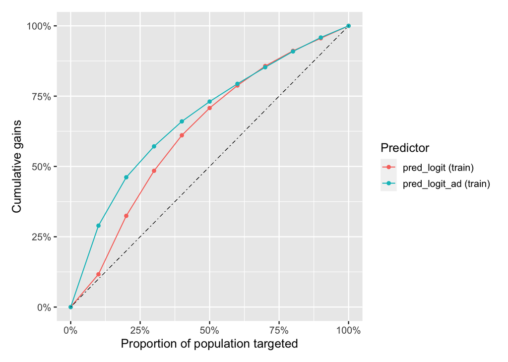

```r
plot(result, plots = "gains", custom = FALSE)
```

```r
result <- confusion(
  cg_ad_treatment,
  pred = c("pred_logit", "pred_logit_ad"),
  rvar = "converted",
  lev = "yes",
  train = "Training",
  data_filter = "rnd_30k == 0"
)
summary(result)
```

```
Confusion matrix
Data       : cg_ad_treatment
Filter     : rnd_30k == 0
Results for: Training
Predictors : pred_logit, pred_logit_ad
Response   : converted
Level      : yes in converted
Cost:Margin: 1 : 2
Scale      : 1

     Type     Predictor    TP    FP      TN     FN   total   TPR   TNR precision Fscore
 Training    pred_logit   385 3,948 100,317 15,350 120,000 0.024 0.962     0.089  0.038
 Training pred_logit_ad 1,225   772 103,493 14,510 120,000 0.078 0.993     0.613  0.138

     Type     Predictor accuracy  kappa     profit  index   ROME contact   AUC
 Training    pred_logit    0.839 -0.019 -3,563.000 -7.865 -0.822   0.036 0.644
 Training pred_logit_ad    0.873  0.112    453.000  1.000  0.227   0.017 0.703
```

AUC for “organic” model on test set - 0.644

AUC for new “ad” model on test set - 0.703

The comparison between the “organic” and “ad” models in terms of AUC values - 0.644 for the organic and 0.703 for the ad model - highlights the concept of situational invariance. This concept refers to the idea that a model’s effectiveness can vary depending on the context or environment in which it is applied.

In this case, the “organic” model, developed under normal conditions without advertising influence, performs less effectively in an environment where ad campaigns are active. The “ad” model, on the other hand, is specifically tailored for the scenario where customers are exposed to ads, hence its higher AUC value.

Examining the gains curves, where the “ad” model’s curve ascends more steeply than the “organic” model’s. This indicates that the “ad” model is more proficient at identifying and engaging with potential customers who are more responsive to the advertising, thus leading to a higher concentration of conversions earlier in the targeting process.

This difference underscores the importance of adapting predictive models to the specific circumstances in which they will be used, as a model that works well in one situation might not perform as effectively in another.

3. Calculate the profit improvement of using the “ad” model instead of the “organic” model to target the best 30,000 customers in the “cg_ad_treatment” data that are not in “rnd_30k == 1”. (2 points)

```r
result <- pivotr(
  cg_ad_treatment,
  cvars = "converted",
  data_filter = "rnd_30k == 0",
  arr = "desc(pred_logit_ad)",
  rows = "1:30000",
  nr = Inf
)
# summary(result)
dtab(result, dec = 5, caption = "") %>% render()
```

[interactive table not shown]

```r
result <- pivotr(
  cg_ad_treatment,
  cvars = "converted",
  normalize = "total",
  data_filter = "rnd_30k == 0",
  arr = "desc(pred_logit_ad)",
  rows = "1:30000",
  nr = Inf
)
# summary(result)
dtab(result, dec = 5, caption = "") %>% render()
```

[interactive table not shown]

```r
response_rate_ad = 0.2739
converted_yes_ad = 8217
profit_ad = converted_yes_ad * revenue - customers * cost
profit_ad
```

```
[1] 78172.83
```

```r
profit_improvement = profit_ad - profit_group3
profit_improvement
```

```
[1] 26457.35
```

Profit from “ad” model - 78,172.83

Profit improvement if “ad” model is used instead of the “organic” model to target the best 30,000 customers is 26,457.35

4. Compare the permutation importance plot of the “organic” and the “ad” model. Explain why you think the plots differ. (2 points)

Permutation Importance plot of the “organic” model

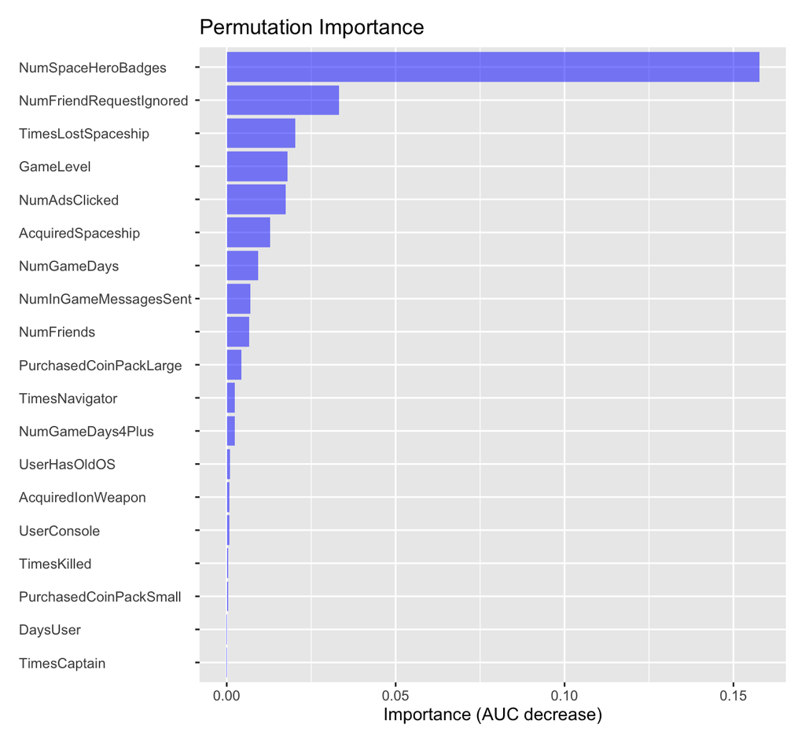

```r
plot(lr_organic, plots = "vip", custom = FALSE)
```

Permutation Importance plot of the “ad” model

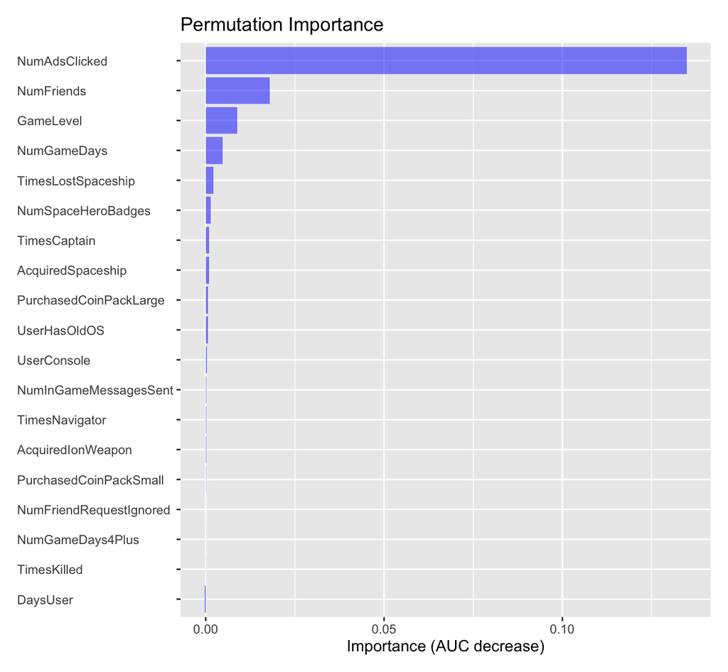

```r
plot(lr_ad, plots = "vip", custom = FALSE)
```

The permutation importance plots show distinct feature significance between the “organic” and “ad” models, indicating context-specific influences on user behavior and underscore the situational invariance between the two models. In the “organic” model, engagement metrics like ‘NumSpaceHeroBadges’ are crucial, whereas in the “ad” model, ‘NumAdsClicked’ gains prominence, reflecting the impact of ad interaction on conversion likelihood in scenarios where advertising is present.This aligns with previous insights from AUC and gains curves, where the “ad” model’s performance advantage in an ad-influenced context is evident.

#### Part V: Better Models, Better Predictions (6 points)

Mi Haruki was impressed by how much performance improved when model was retrained on the ad treatment data rather than organic data. However, she knew that the analytics team was not done yet: “I know we have been trying to keep the models simple and perhaps the logistic regression is what we go with. However, I want to you apply machine learning models to see if they can help improve our predictions and performance further.”

1. Train a neural network on the random sample of customers who were exposed to the ad campaign (i.e., rnd_30k == 1). (2 points)

Neural Network with 1 hidden layer - pred_nn1

```r
result <- nn(
  cg_ad_treatment,
  rvar = "converted",
  evar = c(
    "GameLevel", "NumGameDays",
    "NumGameDays4Plus", "NumInGameMessagesSent",
    "NumSpaceHeroBadges",
    "NumFriendRequestIgnored",
    "NumFriends", "AcquiredSpaceship",
    "AcquiredIonWeapon",
    "TimesLostSpaceship",
    "TimesKilled", "TimesCaptain",
    "TimesNavigator", "PurchasedCoinPackSmall",
    "PurchasedCoinPackLarge",
    "NumAdsClicked", "DaysUser",
    "UserConsole", "UserHasOldOS"
  ),
  lev = "yes",
  seed = 1234,
  data_filter = "rnd_30k == 1"
)
summary(result, prn = TRUE)
```

```
Neural Network
Activation function  : Logistic (classification)
Data                 : cg_ad_treatment
Filter               : rnd_30k == 1
Response variable    : converted
Level                : yes in converted
Explanatory variables: GameLevel, NumGameDays, NumGameDays4Plus, NumInGameMessagesSent, NumSpaceHeroBadges, NumFriendRequestIgnored, NumFriends, AcquiredSpaceship, AcquiredIonWeapon, TimesLostSpaceship, TimesKilled, TimesCaptain, TimesNavigator, PurchasedCoinPackSmall, PurchasedCoinPackLarge, NumAds…
Network size         : 1
Parameter decay      : 0.5
Seed                 : 1234
Network              : 19-1-1 with 22 weights
Nr obs               : 30,000
Weights              :
    b->h1  i1->h1  i2->h1  i3->h1  i4->h1  i5->h1  i6->h1  i7->h1  i8->h1  i9->h1 i10->h1 i11->h1
     0.82   -0.33   -0.23   -0.06    0.04   -0.07   -0.02   -0.38   -0.10    0.11    0.18    0.01
  i12->h1 i13->h1 i14->h1 i15->h1 i16->h1 i17->h1 i18->h1 i19->h1
    -0.09    0.03   -0.05   -0.19   -1.27   -0.05    0.06    0.22
   b->o h1->o
   0.86 -4.38
```

```r
pred <- predict(result, pred_data = cg_ad_treatment)
print(pred, n = 10)
```

```
Neural Network
Data                 : cg_ad_treatment
Filter               : rnd_30k == 1
Response variable    : converted
Level(s)             : yes in converted
Explanatory variables: GameLevel, NumGameDays, NumGameDays4Plus, NumInGameMessagesSent, NumSpaceHeroBadges, NumFriendRequestIgnored, NumFriends, AcquiredSpaceship, AcquiredIonWeapon, TimesLostSpaceship, TimesKilled, TimesCaptain, TimesNavigator, PurchasedCoinPackSmall, PurchasedCoinPackLarge, NumAds…
Prediction dataset   : cg_ad_treatment
Rows shown           : 10 of 150,000

 GameLevel NumGameDays NumGameDays4Plus NumInGameMessagesSent NumSpaceHeroBadges NumFriendRequestIgnored NumFriends AcquiredSpaceship AcquiredIonWeapon TimesLostSpaceship TimesKilled TimesCaptain TimesNavigator PurchasedCoinPackSmall
         6          16                0                     0                  0                       0          0               yes                no                  0           0            0              0                     no
         2           8                0                     0                  0                       5          4                no                no                  0           0            8              0                    yes
         6           1                0                     0                  0                       0          0                no                no                  0           0            0              0                     no
         7          16                0                   102                  1                       0        194                no                no                  0           0            0              0                    yes
        10           1                1                   233                  0                      23          0                no                no                  3           0            5              0                     no
         1           6                0                     0                  0                       0          0                no                no                  4           0            0              0                     no
         2           4                0                     0                  0                       0          0               yes                no                  3           0            0              0                     no
         1           9                0                     0                  0                       0          0                no                no                  0           0            0              0                    yes
         8           9                0                     4                  0                      98          2                no                no                  1           0            0              9                     no
        10          11                0                     0                  9                       0        244                no                no                  0           0            4              0                     no
 PurchasedCoinPackLarge NumAdsClicked DaysUser UserConsole UserHasOldOS Prediction
                     no            11     1827          no           no      0.123
                     no             3     1889          no          yes      0.050
                    yes             2     1948         yes           no      0.057
                    yes            21     3409         yes          yes      0.352
                    yes             4     2922         yes           no      0.076
                    yes             9     3470         yes           no      0.077
                     no             3     4108         yes           no      0.054
                    yes             0     2892          no           no      0.051
                     no            14     3835         yes           no      0.148
                     no             9     1461          no           no      0.192
```

```r
cg_ad_treatment <- store(cg_ad_treatment, pred, name = "pred_nn1")
```

```r
result <- nn(
  cg_ad_treatment,
  rvar = "converted",
  evar = c(
    "GameLevel", "NumGameDays",
    "NumGameDays4Plus", "NumInGameMessagesSent",
    "NumSpaceHeroBadges",
    "NumFriendRequestIgnored",
    "NumFriends", "AcquiredSpaceship",
    "AcquiredIonWeapon",
    "TimesLostSpaceship",
    "TimesKilled", "TimesCaptain",
    "TimesNavigator", "PurchasedCoinPackSmall",
    "PurchasedCoinPackLarge",
    "NumAdsClicked", "DaysUser",
    "UserConsole", "UserHasOldOS"
  ),
  lev = "yes",
  size = 10,
  seed = 1234,
  data_filter = "rnd_30k == 1"
)
summary(result, prn = TRUE)
```

```
Neural Network
Activation function  : Logistic (classification)
Data                 : cg_ad_treatment
Filter               : rnd_30k == 1
Response variable    : converted
Level                : yes in converted
Explanatory variables: GameLevel, NumGameDays, NumGameDays4Plus, NumInGameMessagesSent, NumSpaceHeroBadges, NumFriendRequestIgnored, NumFriends, AcquiredSpaceship, AcquiredIonWeapon, TimesLostSpaceship, TimesKilled, TimesCaptain, TimesNavigator, PurchasedCoinPackSmall, PurchasedCoinPackLarge, NumAds…
Network size         : 10
Parameter decay      : 0.5
Seed                 : 1234
Network              : 19-10-1 with 211 weights
Nr obs               : 30,000
Weights              :
    b->h1  i1->h1  i2->h1  i3->h1  i4->h1  i5->h1  i6->h1  i7->h1  i8->h1  i9->h1 i10->h1 i11->h1
     1.26   -0.36    0.04   -0.30   -0.32   -0.03    0.18   -0.16   -0.46    0.60    0.06   -0.08
  i12->h1 i13->h1 i14->h1 i15->h1 i16->h1 i17->h1 i18->h1 i19->h1
     0.11   -0.94   -1.01   -0.44   -1.49   -1.04    0.33    0.26
    b->h2  i1->h2  i2->h2  i3->h2  i4->h2  i5->h2  i6->h2  i7->h2  i8->h2  i9->h2 i10->h2 i11->h2
    -3.88    0.26    0.06    0.07    0.16   -1.75   -0.76   -8.03    0.21    0.04   -0.75   -0.13
  i12->h2 i13->h2 i14->h2 i15->h2 i16->h2 i17->h2 i18->h2 i19->h2
    -0.03   -0.15   -0.49    0.55   -0.93    0.65   -0.04   -0.34
    b->h3  i1->h3  i2->h3  i3->h3  i4->h3  i5->h3  i6->h3  i7->h3  i8->h3  i9->h3 i10->h3 i11->h3
    -0.79    0.52    0.53    0.07   -1.21    0.32   -0.20    1.12   -0.42   -0.49    0.26    0.54
  i12->h3 i13->h3 i14->h3 i15->h3 i16->h3 i17->h3 i18->h3 i19->h3
     0.42   -0.61   -0.15    0.37   -2.48    1.01   -0.62   -0.60
    b->h4  i1->h4  i2->h4  i3->h4  i4->h4  i5->h4  i6->h4  i7->h4  i8->h4  i9->h4 i10->h4 i11->h4
     0.32    0.64    0.30   -0.34    0.14    0.58   -1.13   -0.86   -1.38   -0.19   -0.08   -0.84
  i12->h4 i13->h4 i14->h4 i15->h4 i16->h4 i17->h4 i18->h4 i19->h4
    -0.48   -0.82    0.12    0.36    0.93   -1.42    0.76   -0.99
    b->h5  i1->h5  i2->h5  i3->h5  i4->h5  i5->h5  i6->h5  i7->h5  i8->h5  i9->h5 i10->h5 i11->h5
    -0.75    0.27    0.25    0.26    0.49    0.21   -0.25    0.25   -0.38   -1.28   -0.81    0.47
  i12->h5 i13->h5 i14->h5 i15->h5 i16->h5 i17->h5 i18->h5 i19->h5
     0.25    0.06    1.74    1.12   -0.48    0.15   -0.93   -0.73
    b->h6  i1->h6  i2->h6  i3->h6  i4->h6  i5->h6  i6->h6  i7->h6  i8->h6  i9->h6 i10->h6 i11->h6
    -0.33   -0.81   -0.63   -0.74   -0.33   -5.62    1.85   -0.18   -1.03    0.29    1.16    0.20
  i12->h6 i13->h6 i14->h6 i15->h6 i16->h6 i17->h6 i18->h6 i19->h6
    -0.13    0.36    0.43   -0.60    0.81   -0.60   -0.82    0.48
    b->h7  i1->h7  i2->h7  i3->h7  i4->h7  i5->h7  i6->h7  i7->h7  i8->h7  i9->h7 i10->h7 i11->h7
     0.25   -1.70   -0.18   -0.35    0.12   -0.12    1.29    0.52   -0.52    0.51   -0.06   -0.10
  i12->h7 i13->h7 i14->h7 i15->h7 i16->h7 i17->h7 i18->h7 i19->h7
     0.46    0.32    0.33    0.88   -0.28    0.19   -1.33   -0.96
    b->h8  i1->h8  i2->h8  i3->h8  i4->h8  i5->h8  i6->h8  i7->h8  i8->h8  i9->h8 i10->h8 i11->h8
    -1.07   -0.76    0.74   -0.45   -0.41    1.17   -0.55    0.85   -0.83    0.02   -0.75   -0.18
  i12->h8 i13->h8 i14->h8 i15->h8 i16->h8 i17->h8 i18->h8 i19->h8
     0.57    0.03   -0.42    0.67   -1.18    0.94   -0.69   -1.97
    b->h9  i1->h9  i2->h9  i3->h9  i4->h9  i5->h9  i6->h9  i7->h9  i8->h9  i9->h9 i10->h9 i11->h9
     0.63   -0.61   -0.02   -0.23    0.35   -3.92    0.29   -0.64   -0.37   -0.41   -2.37    0.68
  i12->h9 i13->h9 i14->h9 i15->h9 i16->h9 i17->h9 i18->h9 i19->h9
    -0.01    0.05    0.66    0.11    0.60   -0.21   -1.05    0.85
    b->h10  i1->h10  i2->h10  i3->h10  i4->h10  i5->h10  i6->h10  i7->h10  i8->h10  i9->h10 i10->h10
     -2.61     2.76    -0.18    -0.21    -0.30    -2.27     1.34     0.24    -0.68     0.06     1.44
  i11->h10 i12->h10 i13->h10 i14->h10 i15->h10 i16->h10 i17->h10 i18->h10 i19->h10
      0.25     0.24    -0.07     0.13    -0.41     0.57    -0.46    -0.44    -0.01
    b->o  h1->o  h2->o  h3->o  h4->o  h5->o  h6->o  h7->o  h8->o  h9->o h10->o
   -1.14  -2.70  -5.28   2.39   1.83  -2.86  -4.70   3.02  -2.28   2.79   2.91
```

```r
pred <- predict(result, pred_data = cg_ad_treatment)
print(pred, n = 10)
```

```
Neural Network
Data                 : cg_ad_treatment
Filter               : rnd_30k == 1
Response variable    : converted
Level(s)             : yes in converted
Explanatory variables: GameLevel, NumGameDays, NumGameDays4Plus, NumInGameMessagesSent, NumSpaceHeroBadges, NumFriendRequestIgnored, NumFriends, AcquiredSpaceship, AcquiredIonWeapon, TimesLostSpaceship, TimesKilled, TimesCaptain, TimesNavigator, PurchasedCoinPackSmall, PurchasedCoinPackLarge, NumAds…
Prediction dataset   : cg_ad_treatment
Rows shown           : 10 of 150,000

 GameLevel NumGameDays NumGameDays4Plus NumInGameMessagesSent NumSpaceHeroBadges NumFriendRequestIgnored NumFriends AcquiredSpaceship AcquiredIonWeapon TimesLostSpaceship TimesKilled TimesCaptain TimesNavigator PurchasedCoinPackSmall
         6          16                0                     0                  0                       0          0               yes                no                  0           0            0              0                     no
         2           8                0                     0                  0                       5          4                no                no                  0           0            8              0                    yes
         6           1                0                     0                  0                       0          0                no                no                  0           0            0              0                     no
         7          16                0                   102                  1                       0        194                no                no                  0           0            0              0                    yes
        10           1                1                   233                  0                      23          0                no                no                  3           0            5              0                     no
         1           6                0                     0                  0                       0          0                no                no                  4           0            0              0                     no
         2           4                0                     0                  0                       0          0               yes                no                  3           0            0              0                     no
         1           9                0                     0                  0                       0          0                no                no                  0           0            0              0                    yes
         8           9                0                     4                  0                      98          2                no                no                  1           0            0              9                     no
        10          11                0                     0                  9                       0        244                no                no                  0           0            4              0                     no
 PurchasedCoinPackLarge NumAdsClicked DaysUser UserConsole UserHasOldOS Prediction
                     no            11     1827          no           no      0.111
                     no             3     1889          no          yes      0.024
                    yes             2     1948         yes           no      0.048
                    yes            21     3409         yes          yes      0.556
                    yes             4     2922         yes           no      0.035
                    yes             9     3470         yes           no      0.065
                     no             3     4108         yes           no      0.026
                    yes             0     2892          no           no      0.023
                     no            14     3835         yes           no      0.081
                     no             9     1461          no           no      0.076
```

```r
cg_ad_treatment <- store(cg_ad_treatment, pred, name = "pred_nn10")
```

2. Compare the performance of the neural network “ad” model and the logistic regression “ad” model from Part IV using data from the 120,000K customers that are not in group 2. Use gains curves and AUC for the comparison. What do you find? (2 points)

```r
result <- evalbin(
  cg_ad_treatment,
  pred = c("pred_logit_ad", "pred_nn10"),
  rvar = "converted",
  lev = "yes",
  train = "Test",
  data_filter = "rnd_30k == 1"
)
summary(result, prn = FALSE)
```

```
Evaluate predictions for binary response models
Data        : cg_ad_treatment
Filter      : rnd_30k == 1
Results for : Test
Predictors  : pred_logit_ad, pred_nn10
Response    : converted
Level       : yes in converted
Bins        : 10
Cost:Margin : 1 : 2
Scale       : 1
```

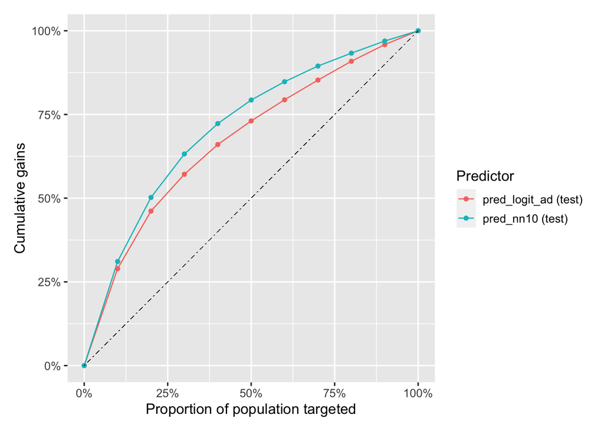

```r
plot(result, plots = "gains", custom = FALSE)
```

```r
result <- confusion(
  cg_ad_treatment,
  pred = c("pred_logit_ad", "pred_nn1", "pred_nn10"),
  rvar = "converted",
  lev = "yes",
  train = "Test",
  data_filter = "rnd_30k == 1"
)
summary(result)
```

```
Confusion matrix
Data       : cg_ad_treatment
Filter     : rnd_30k == 1
Results for: Test
Predictors : pred_logit_ad, pred_nn1, pred_nn10
Response   : converted
Level      : yes in converted
Cost:Margin: 1 : 2
Scale      : 1

 Type     Predictor    TP    FP      TN     FN   total   TPR   TNR precision Fscore
 Test pred_logit_ad 1,225   772 103,493 14,510 120,000 0.078 0.993     0.613  0.138
 Test      pred_nn1 1,204   763 103,502 14,531 120,000 0.077 0.993     0.612  0.136
 Test     pred_nn10 1,738 1,407 102,858 13,997 120,000 0.110 0.987     0.553  0.184

 Type     Predictor accuracy kappa  profit index  ROME contact   AUC
 Test pred_logit_ad    0.873 0.112 453.000 1.000 0.227   0.017 0.703
 Test      pred_nn1    0.873 0.110 441.000 0.974 0.224   0.016 0.703
 Test     pred_nn10    0.872 0.147 331.000 0.731 0.105   0.026 0.747
```

AUC for logistic regression “ad” model on test set - 0.703

AUC for neural network “ad” model on test set - 0.747

The neural network “ad” model, with an AUC of 0.747, outperforms the logistic regression “ad” model, which has an AUC of 0.703 on the test set. The gains curve visually supports this, showing that the neural network model (blue line) is consistently above the logistic regression model (red line) across most of the proportion of the population targeted, indicating a higher efficiency in capturing conversions. The steeper ascent of the neural network’s gains curve suggests it is better at ranking the potential converters higher than the logistic model.

3. Calculate the profit improvement of using the neural network “ad” model and the logistic regression “ad” model to target the best 30,000 customers out of the 120,000K customers that are not in group 2. (2 points)

```r
result <- pivotr(
  cg_ad_treatment,
  cvars = "converted",
  data_filter = "rnd_30k == 0",
  arr = "desc(pred_nn10)",
  rows = "1:30000",
  nr = Inf
)
# summary(result)
dtab(result, dec = 5, caption = "") %>% render()
```

[interactive table not shown]

```r
result <- pivotr(
  cg_ad_treatment,
  cvars = "converted",
  normalize = "total",
  data_filter = "rnd_30k == 0",
  arr = "desc(pred_nn10)",
  rows = "1:30000",
  nr = Inf
)
# summary(result)
dtab(result, dec = 5, caption = "") %>% render()
```

[interactive table not shown]

```r
response_rate_nn = 0.30060
converted_yes_nn = 9018
profit_nn = converted_yes_nn * revenue - customers * cost
profit_nn
```

```
[1] 90179.82
```

```r
profit_improvement_nn = profit_nn - profit_ad
profit_improvement_nn
```

```
[1] 12006.99
```

Profit from neural network “ad” model - 90,179.82

Profit improvement if neural network “ad” model is used to target the best 30,000 customers is 12,006.99

#### Extra credit (6 points)

4. Train a random forest on the sample of customers who were exposed to the ad campaign. (2 points)

```r
result <- rforest(
  cg_ad_treatment,
  rvar = "converted",
  evar = c(
    "GameLevel", "NumGameDays",
    "NumGameDays4Plus", "NumInGameMessagesSent",
    "NumSpaceHeroBadges",
    "NumFriendRequestIgnored",
    "NumFriends", "AcquiredSpaceship",
    "AcquiredIonWeapon",
    "TimesLostSpaceship",
    "TimesKilled", "TimesCaptain",
    "TimesNavigator", "PurchasedCoinPackSmall",
    "PurchasedCoinPackLarge",
    "NumAdsClicked", "DaysUser",
    "UserConsole", "UserHasOldOS"
  ),
  lev = "yes",
  mtry = 4,
  num.trees = 700,
  min.node.size = 3,
  sample.fraction = 0.6,
  seed = 1234,
  data_filter = "rnd_30k == 1"
)
summary(result)
```

```
Random Forest (Ranger)
Type                 : Classification
Data                 : cg_ad_treatment
Filter               : rnd_30k == 1
Response variable    : converted
Level                : yes in converted
Explanatory variables: GameLevel, NumGameDays, NumGameDays4Plus, NumInGameMessagesSent, NumSpaceHeroBadges, NumFriendRequestIgnored, NumFriends, AcquiredSpaceship, AcquiredIonWeapon, TimesLostSpaceship, TimesKilled, TimesCaptain, TimesNavigator, PurchasedCoinPackSmall, PurchasedCoinPackLarge, NumAds…
Mtry                 : 4
Number of trees      : 700
Min node size        : 3
Sample fraction      : 0.6
Number of threads    : 12
Nr obs               : 30,000
OOB prediction error : 0.098
```

```r
pred <- predict(result, pred_data = cg_ad_treatment, OOB = FALSE)
print(pred, n = 10)
```

```
Random Forest
Data                 : cg_ad_treatment
Filter               : rnd_30k == 1
Response variable    : converted
Level(s)             : yes in converted
Explanatory variables: GameLevel, NumGameDays, NumGameDays4Plus, NumInGameMessagesSent, NumSpaceHeroBadges, NumFriendRequestIgnored, NumFriends, AcquiredSpaceship, AcquiredIonWeapon, TimesLostSpaceship, TimesKilled, TimesCaptain, TimesNavigator, PurchasedCoinPackSmall, PurchasedCoinPackLarge, NumAds…
Prediction dataset   : cg_ad_treatment
Additional arguments : OOB = FALSE
Rows shown           : 10 of 150,000

 GameLevel NumGameDays NumGameDays4Plus NumInGameMessagesSent NumSpaceHeroBadges NumFriendRequestIgnored NumFriends AcquiredSpaceship AcquiredIonWeapon TimesLostSpaceship TimesKilled TimesCaptain TimesNavigator PurchasedCoinPackSmall
         6          16                0                     0                  0                       0          0               yes                no                  0           0            0              0                     no
         2           8                0                     0                  0                       5          4                no                no                  0           0            8              0                    yes
         6           1                0                     0                  0                       0          0                no                no                  0           0            0              0                     no
         7          16                0                   102                  1                       0        194                no                no                  0           0            0              0                    yes
        10           1                1                   233                  0                      23          0                no                no                  3           0            5              0                     no
         1           6                0                     0                  0                       0          0                no                no                  4           0            0              0                     no
         2           4                0                     0                  0                       0          0               yes                no                  3           0            0              0                     no
         1           9                0                     0                  0                       0          0                no                no                  0           0            0              0                    yes
         8           9                0                     4                  0                      98          2                no                no                  1           0            0              9                     no
        10          11                0                     0                  9                       0        244                no                no                  0           0            4              0                     no
 PurchasedCoinPackLarge NumAdsClicked DaysUser UserConsole UserHasOldOS   yes    no
                     no            11     1827          no           no 0.008 0.992
                     no             3     1889          no          yes 0.074 0.926
                    yes             2     1948         yes           no 0.051 0.949
                    yes            21     3409         yes          yes 0.323 0.677
                    yes             4     2922         yes           no 0.054 0.946
                    yes             9     3470         yes           no 0.034 0.966
                     no             3     4108         yes           no 0.029 0.971
                    yes             0     2892          no           no 0.023 0.977
                     no            14     3835         yes           no 0.287 0.713
                     no             9     1461          no           no 0.131 0.869
```

```r
cg_ad_treatment <- store(cg_ad_treatment, pred, name = "pred_rf")
```

5. Compare the performance of the random forest “ad” model and the logistic regression “ad” model from Part IV using data from the 120,000K customers that are not in group 2. Use gains curves and AUC for the comparison. What do you find? (2 points)

```r
result <- evalbin(
  cg_ad_treatment,
  pred = c("pred_logit_ad", "pred_rf"),
  rvar = "converted",
  lev = "yes",
  train = "Training",
  data_filter = "rnd_30k == 0"
)
summary(result, prn = FALSE)
```

```
Evaluate predictions for binary response models
Data        : cg_ad_treatment
Filter      : rnd_30k == 0
Results for : Training
Predictors  : pred_logit_ad, pred_rf
Response    : converted
Level       : yes in converted
Bins        : 10
Cost:Margin : 1 : 2
Scale       : 1
```

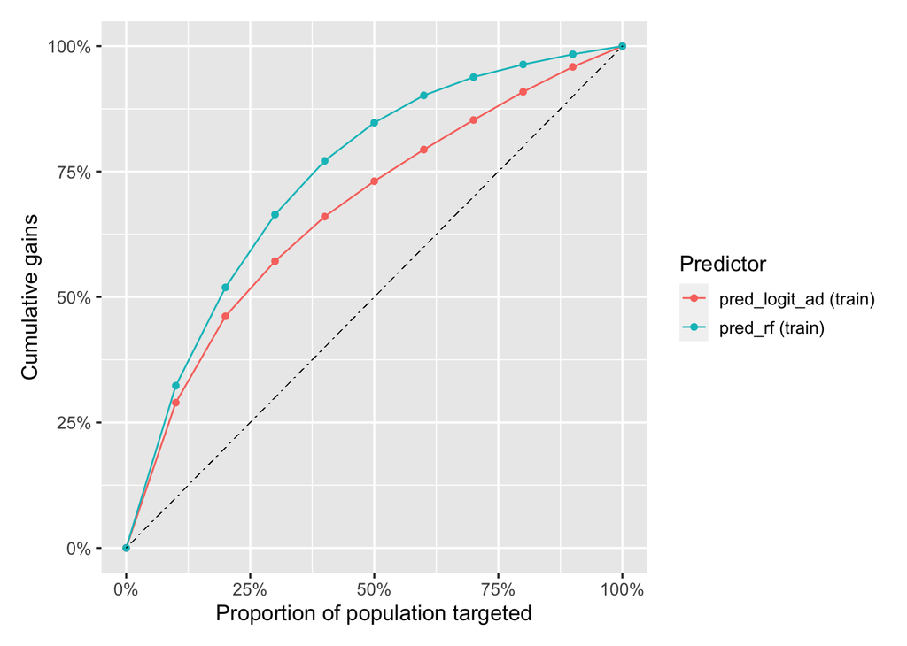

```r
plot(result, plots = "gains", custom = FALSE)
```

```r
result <- confusion(
  cg_ad_treatment,
  pred = c("pred_logit_ad", "pred_rf"),
  rvar = "converted",
  lev = "yes",
  train = "Training",
  data_filter = "rnd_30k == 0"
)
summary(result)
```

```
Confusion matrix
Data       : cg_ad_treatment
Filter     : rnd_30k == 0
Results for: Training
Predictors : pred_logit_ad, pred_rf
Response   : converted
Level      : yes in converted
Cost:Margin: 1 : 2
Scale      : 1

     Type     Predictor    TP  FP      TN     FN   total   TPR   TNR precision Fscore
 Training pred_logit_ad 1,225 772 103,493 14,510 120,000 0.078 0.993     0.613  0.138
 Training       pred_rf 1,603 959 103,306 14,132 120,000 0.102 0.991     0.626  0.175

     Type     Predictor accuracy kappa  profit index  ROME contact   AUC
 Training pred_logit_ad    0.873 0.112 453.000 0.703 0.227   0.017 0.703
 Training       pred_rf    0.874 0.144 644.000 1.000 0.251   0.021 0.782
```

AUC for logistic regression “ad” model on test set - 0.703

AUC for random forest “ad” model on test set - 0.782

The random forest “ad” model, with an AUC of 0.782, demonstrates a superior performance compared to the logistic regression “ad” model, which has an AUC of 0.703. The gains curve corroborates this by showing that the random forest model (blue line) consistently lies above the logistic regression model (red line), suggesting it is more effective at prioritizing individuals who are likely to convert. This is reflected in the steeper slope of the random forest’s gains curve, indicating a more efficient identification of higher-probability converters early in the targeting process.

6. Calculate the profit improvement of using the random forest “ad” model and the logistic regression “ad” model to target the best 30,000 customers out of the 120,000K customers that are not in group 2. (2 points)

```r
result <- pivotr(
  cg_ad_treatment,
  cvars = "converted",
  data_filter = "rnd_30k == 0",
  arr = "desc(pred_rf)",
  rows = "1:30000",
  nr = Inf
)
# summary(result)
dtab(result, dec = 5, caption = "") %>% render()
```

[interactive table not shown]

```r
result <- pivotr(
  cg_ad_treatment,
  cvars = "converted",
  normalize = "total",
  data_filter = "rnd_30k == 0",
  arr = "desc(pred_rf)",
  rows = "1:30000",
  nr = Inf
)
# summary(result)
dtab(result, dec = 5, caption = "") %>% render()
```

[interactive table not shown]

```r
response_rate_rf = 0.31293
converted_yes_rf = 9388
profit_rf = converted_yes_rf * revenue - customers * cost
profit_rf
```

```
[1] 95726.12
```

```r
profit_improvement_rf = profit_rf - profit_ad
profit_improvement_rf
```

```
[1] 17553.29
```

Profit from random forest “ad” model - 95,726.12

Profit improvement if random forest “ad” model is used to target the best 30,000 customers is 17,553.29